# Q1 [Data Preprocessing]

(10%) 資料前處理是一個重要的工作，利用UCI的"Adult" dataset https://archive.ics.uci.edu/ml/datasets/Adult來練習資料前處理。我們使用這個資料集的方式是用來建構預測最後一個收入欄位是'>50K'或'<=50K'。這個資料集已經先切好了Training跟Test。我們將會沿用這個切割。

資料前處理包含以下工作:

- 生成以下numpy變數: x_train(訓練特徵)、y_train(訓練標籤)、x_test(測試特徵)、y_test(測試標籤)。用一個Dictionary組織將這些變數，其中Key為變數名稱，Value為之前生成的變數內容。
- 最後一欄為標籤，將'>50K'與'<=50K'轉成1跟0。其他欄位為特徵。
- 把所有含有缺值的Rows刪除。
- 所有數值欄位標準化(均數為0，變異數為1)。測試資料特徵需用訓練資料的均數與變異數標準化。
- 所有類別欄位(如native-country與workclass)都應使用"1-of-K"轉換成0與1的欄位。
- 我們只考慮在訓練資料中出現超過(含)10次的特徵值。如果一個特徵值出現不到10次，則刪除這個特徵值所對應的1-of-K欄位。
- 你可以使用sklearn中的工具函數進行1-of-K encoding與變數標準化。

### 用pandas將資料匯入

```python
import pandas as pd

train_data = pd.read_table('adult.data', header=None, sep=',\s', engine='python')
test_data = pd.read_table('adult.test', header=None, skiprows=1, sep=',\s', engine='python')
train_data.columns = ['age', 'workclass', 'fnlwgt', 'education', 'educational-num', 'marital-status',
                      'occupation', 'relationship', 'race', 'gender', 'capital-gain', 'capital-loss', 'hours-per-week',
                      'native-country', 'y_label']
test_data.columns = ['age', 'workclass', 'fnlwgt', 'education', 'educational-num', 'marital-status',
                     'occupation', 'relationship', 'race', 'gender', 'capital-gain', 'capital-loss', 'hours-per-week',
                     'native-country', 'y_label']
```

### 觀察出資料有些地方需要修正，以利之後的模型預測

1.test資料 ylabel欄位最後有一個. 2.train和test資料 ylabel欄位前後都留有空白

```python
test_data['y_label'] = test_data['y_label'].str.replace('.', ' ')
test_data['y_label'] = test_data['y_label'].str.strip()
train_data['y_label'] = train_data['y_label'].str.strip()
```

### ylabel為標籤，將'>50K'與'<=50K'轉成1跟0

##### 方法1

```python
def transform50K(x):
    if x == '>50K':
        return 1
    else:
        return 0


train_data['y_label'] = train_data['y_label'].apply(transform50K)
test_data['y_label'] = test_data['y_label'].apply(transform50K)
```

##### 方法2

```python
from sklearn.preprocessing import LabelEncoder

le=LabelEncoder()
train_data['y_label']=le.fit_transform(train_data['y_label'].values.tolist())
test_data['y_label']=le.fit_transform(test_data['y_label'].values.tolist())
```

### 觀察出資料的缺失值為?，必須轉換為nan，方便之後刪除

```python
import numpy as np

train_data = train_data.replace('?', np.nan)
test_data = test_data.replace('?', np.nan)

train_data.dropna(inplace=True)
test_data.dropna(inplace=True)
```

### 所有數值欄位標準化(均數為0，變異數為1)。測試資料特徵需用訓練資料的均數與變異數標準化

```python
from sklearn.preprocessing import StandardScaler

num_cols = ['capital-loss', 'hours-per-week', 'capital-gain', 'educational-num', 'age', 'fnlwgt']

train_data1 = train_data.copy()
train_data1 = train_data1[num_cols]
test_data1 = test_data.copy()
test_data1 = test_data1[num_cols]

s1 = StandardScaler()
s1.fit(train_data1)
stan_train = s1.transform(train_data1)
stan_test = s1.transform(test_data1)
```

### 所有類別欄位(如native-country與workclass)都應使用"1-of-K"轉換成0與1的欄位。

```python
from sklearn.preprocessing import OneHotEncoder

cat_cols = ['relationship', 'race', 'gender', 'occupation', 'education', 'native-country', 'workclass',
            'marital-status']

train_data2 = train_data.copy()
train_data2 = train_data2[cat_cols]
test_data2 = test_data.copy()
test_data2 = test_data2[cat_cols]

s2 = OneHotEncoder(sparse=False)
s2.fit(train_data2)
onehot_train = s2.transform(train_data2)
onehot_test = s2.transform(test_data2)
feature_cols = s2.get_feature_names(cat_cols)
```

### 只考慮在訓練資料中出現超過(含)10次的特徵值。如果一個特徵值出現不到10次，則刪除這個特徵值所對應的1-of-K欄位。

```python
lower10fe = np.where(onehot_train.sum(axis=0) < 10)
onehot_train = np.delete(onehot_train, lower10fe, axis=1)
onehot_test = np.delete(onehot_test, lower10fe, axis=1)
feature_cols = np.delete(feature_cols, lower10fe)
print(feature_cols)
```

```
['relationship_Husband' 'relationship_Not-in-family'
 'relationship_Other-relative' 'relationship_Own-child'
 'relationship_Unmarried' 'relationship_Wife' 'race_Amer-Indian-Eskimo'
 'race_Asian-Pac-Islander' 'race_Black' 'race_Other' 'race_White'
 'gender_Female' 'gender_Male' 'occupation_Adm-clerical'
 'occupation_Craft-repair' 'occupation_Exec-managerial'
 'occupation_Farming-fishing' 'occupation_Handlers-cleaners'
 'occupation_Machine-op-inspct' 'occupation_Other-service'
 'occupation_Priv-house-serv' 'occupation_Prof-specialty'
 'occupation_Protective-serv' 'occupation_Sales' 'occupation_Tech-support'
 'occupation_Transport-moving' 'education_10th' 'education_11th'
 'education_12th' 'education_1st-4th' 'education_5th-6th'
 'education_7th-8th' 'education_9th' 'education_Assoc-acdm'
 'education_Assoc-voc' 'education_Bachelors' 'education_Doctorate'
 'education_HS-grad' 'education_Masters' 'education_Preschool'
 'education_Prof-school' 'education_Some-college'
 'native-country_Cambodia' 'native-country_Canada' 'native-country_China'
 'native-country_Columbia' 'native-country_Cuba'
 'native-country_Dominican-Republic' 'native-country_Ecuador'
 'native-country_El-Salvador' 'native-country_England'
 'native-country_France' 'native-country_Germany' 'native-country_Greece'
 'native-country_Guatemala' 'native-country_Haiti'
 'native-country_Honduras' 'native-country_Hong' 'native-country_Hungary'
 'native-country_India' 'native-country_Iran' 'native-country_Ireland'
 'native-country_Italy' 'native-country_Jamaica' 'native-country_Japan'
 'native-country_Laos' 'native-country_Mexico' 'native-country_Nicaragua'
 'native-country_Outlying-US(Guam-USVI-etc)' 'native-country_Peru'
 'native-country_Philippines' 'native-country_Poland'
 'native-country_Portugal' 'native-country_Puerto-Rico'
 'native-country_Scotland' 'native-country_South' 'native-country_Taiwan'
 'native-country_Thailand' 'native-country_Trinadad&Tobago'
 'native-country_United-States' 'native-country_Vietnam'
 'native-country_Yugoslavia' 'workclass_Federal-gov' 'workclass_Local-gov'
 'workclass_Private' 'workclass_Self-emp-inc' 'workclass_Self-emp-not-inc'
 'workclass_State-gov' 'workclass_Without-pay' 'marital-status_Divorced'
 'marital-status_Married-AF-spouse' 'marital-status_Married-civ-spouse'
 'marital-status_Married-spouse-absent' 'marital-status_Never-married'
 'marital-status_Separated' 'marital-status_Widowed']
```

### 將前處理後的資料轉換成DataFrame

```python
post_train_data = np.hstack((stan_train, onehot_train))
post_test_data = np.hstack((stan_test, onehot_test))

column_names = ['capital-loss', 'hours-per-week', 'capital-gain',
                'educational-num', 'age', 'fnlwgt', 'relationship_Husband',
                'relationship_Not-in-family', 'relationship_Other-relative',
                'relationship_Own-child', 'relationship_Unmarried',
                'relationship_Wife', 'race_Amer-Indian-Eskimo',
                'race_Asian-Pac-Islander', 'race_Black', 'race_Other',
                'race_White', 'gender_Female', 'gender_Male',
                'occupation_Adm-clerical', 'occupation_Craft-repair',
                'occupation_Exec-managerial', 'occupation_Farming-fishing',
                'occupation_Handlers-cleaners', 'occupation_Machine-op-inspct',
                'occupation_Other-service', 'occupation_Priv-house-serv',
                'occupation_Prof-specialty', 'occupation_Protective-serv',
                'occupation_Sales', 'occupation_Tech-support',
                'occupation_Transport-moving', 'education_10th', 'education_11th',
                'education_12th', 'education_1st-4th', 'education_5th-6th',
                'education_7th-8th', 'education_9th', 'education_Assoc-acdm',
                'education_Assoc-voc', 'education_Bachelors',
                'education_Doctorate', 'education_HS-grad', 'education_Masters',
                'education_Preschool', 'education_Prof-school',
                'education_Some-college', 'native-country_Cambodia',
                'native-country_Canada', 'native-country_China',
                'native-country_Columbia', 'native-country_Cuba',
                'native-country_Dominican-Republic', 'native-country_Ecuador',
                'native-country_El-Salvador', 'native-country_England',
                'native-country_France', 'native-country_Germany',
                'native-country_Greece', 'native-country_Guatemala',
                'native-country_Haiti', 'native-country_Honduras',
                'native-country_Hong', 'native-country_Hungary',
                'native-country_India', 'native-country_Iran',
                'native-country_Ireland', 'native-country_Italy',
                'native-country_Jamaica', 'native-country_Japan',
                'native-country_Laos', 'native-country_Mexico',
                'native-country_Nicaragua',
                'native-country_Outlying-US(Guam-USVI-etc)', 'native-country_Peru',
                'native-country_Philippines', 'native-country_Poland',
                'native-country_Portugal', 'native-country_Puerto-Rico',
                'native-country_Scotland', 'native-country_South',
                'native-country_Taiwan', 'native-country_Thailand',
                'native-country_Trinadad&Tobago', 'native-country_United-States',
                'native-country_Vietnam', 'native-country_Yugoslavia',
                'workclass_Federal-gov', 'workclass_Local-gov',
                'workclass_Private', 'workclass_Self-emp-inc',
                'workclass_Self-emp-not-inc', 'workclass_State-gov',
                'workclass_Without-pay', 'marital-status_Divorced',
                'marital-status_Married-AF-spouse',
                'marital-status_Married-civ-spouse',
                'marital-status_Married-spouse-absent',
                'marital-status_Never-married', 'marital-status_Separated',
                'marital-status_Widowed']

post_train_df = pd.DataFrame(post_train_data, columns=column_names)
post_test_df = pd.DataFrame(post_test_data, columns=column_names)
```

### 製作成字典資料結構

```python
adult50k = {
    'x_train': post_train_data,
    'x_test': post_test_data,
    'y_train': train_data['y_label'],
    'y_test': test_data['y_label'],
}
```

### 進行資料驗證

```python
import pickle

dsfile = 'adult_m50k.pickle'
with open(dsfile, 'rb') as fh1:
    adult50kp = pickle.load(fh1)

x_train = adult50kp['x_train']
y_train = adult50kp['y_train']
x_test = adult50kp['x_test']
y_test = adult50kp['y_test']
columnname = adult50kp['columnname']
num_col = adult50kp['num_col']

elems = ['x_train', 'x_test', 'y_train', 'y_test']
for aelem in elems:
    cnomatch = np.sum(adult50kp[aelem] != adult50k[aelem])
    if cnomatch == 0:
        print(aelem, "match!")
    else:
        print(aelem, "%d elements no match!" % cnomatch)

colname = adult50kp['columnname']
print(colname[17:19])

x_train = adult50kp['x_train']
print(x_train[:, 17:19])

print(x_train[:, 17:19].sum(axis=1))
```

```
x_train match!
x_test match!
y_train match!
y_test match!
['gender_Female' 'gender_Male']
[[0. 1.]
 [0. 1.]
 [0. 1.]
 ...
 [1. 0.]
 [0. 1.]
 [1. 0.]]
[1. 1. 1. ... 1. 1. 1.]
```

# Q2 [ROC and AUC]

(35%) Receiver operation characteristic (ROC)曲線以及其線下面積 (Area Under Curve; AUC)為衡量分類器預測能力常用的工具。本題將練習繪製ROC以及計算AUC。 在這之前我們必須載入資料，訓練模型，並進行預測:

```python
import pickle
from sklearn.linear_model import LogisticRegression
import numpy as np
import matplotlib.pyplot as plt
%matplotlib inline

# load dataset
dsfile = 'adult_m50k.pickle'
with open(dsfile, 'rb') as fh1:
    adult50kp = pickle.load(fh1)

#train prediction model
c = 0.3
lr2 = LogisticRegression(solver = 'lbfgs', C= c, max_iter = 1000)
lr2.fit(adult50kp['x_train'], adult50kp['y_train'])
#make prediction
ypred = lr2.predict(adult50kp['x_test'])
ypredprob = lr2.predict_proba(adult50kp['x_test'])
#compute accuracy
ncorrect = np.sum(adult50kp['y_test'] == ypred)
accuracy_sk = ncorrect / adult50kp['y_test'].shape[0]
print("Accuracy = %f" % accuracy_sk)
print(ypredprob.shape)
print(ncorrect)
```

```
Accuracy = 0.848406
(15060, 2)
12777
```

### Q2.1 (17.5%): 基於adult50kp['y_test']與ypredprob繪製ROC Curve

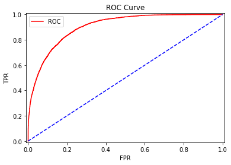

```python
sort_posprob = np.array(sorted(ypredprob, key=lambda x: x[1], reverse=True))
filt_duplicated = np.unique(sort_posprob[:, 1])
y_score = sorted(filt_duplicated, reverse=True)
y_score = np.insert(y_score, 0, y_score[0] + 1)

tpr_list = []
fpr_list = []
for i in y_score:
    tp, fp, tn, fn = np.zeros(4)
    for ypredprob_idx, j in enumerate(ypredprob[:, 1]):
        if j < i:
            if y_test[ypredprob_idx] == 0:
                tn += 1
            else:
                fn += 1
        else:
            if y_test[ypredprob_idx] == 1:
                tp += 1
            else:
                fp += 1
    tpr = tp / (tp + fn)
    fpr = fp / (fp + tn)
    tpr_list.append(tpr)
    fpr_list.append(fpr)

import matplotlib.pyplot as plt

plt.plot(fpr_list, tpr_list, label='ROC', color='red')
plt.plot([0, 1], [0, 1], 'b--')
plt.legend()
plt.xlabel('FPR')
plt.ylabel('TPR')
plt.title('ROC Curve')
plt.xlim(-0.01, 1.01)
plt.ylim(-0.01, 1.01)
plt.show()
```

### Q2.2 (17.5%): 計算繪製出的ROC Curve的AUC

```python
tpr_list1 = tpr_list.copy()
fpr_list1 = fpr_list.copy()
auc_area = 0
for i in range(len(tpr_list1[:-1])):
    auc = (tpr_list1[i] + tpr_list1[i + 1]) * (fpr_list1[i + 1] - fpr_list1[i]) * 0.5
    auc_area += auc
print(f'ROC曲線下AUC面積: {auc_area}')
```

```
ROC曲線下AUC面積: 0.9034910187475556
```

### 使用SKLEARN模組驗證誤差

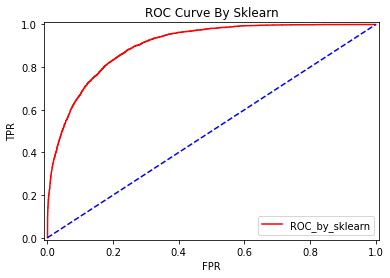

```
Sklearn模組ROC曲線下AUC面積: 0.9034910187476208
面積誤差 : 6.52811138479592e-14
```

```python
from sklearn.metrics import roc_curve
from sklearn.metrics import auc

fpr_sk, tpr_sk, threshold = roc_curve(y_test, ypredprob[:,1], pos_label=1)
auc_area_sk = auc(fpr_sk,tpr_sk)

import matplotlib.pyplot as plt

plt.plot(fpr_sk, tpr_sk, label='ROC_by_sklearn', color='red')
plt.plot([0, 1], [0, 1], 'b--')
plt.legend()
plt.xlabel('FPR')
plt.ylabel('TPR')
plt.title('ROC Curve By Sklearn')
plt.xlim(-0.01, 1.01)
plt.ylim(-0.01, 1.01)
plt.show()

print(f'Sklearn模組ROC曲線下AUC面積: {auc_area_sk}')

print(f'面積誤差 : {np.abs(auc_area-auc_area_sk)}')
```

## Q2 小結

因為將ROC曲線下梯形面積切的非常細(類似微積分黎曼和的作法)因此AUC面積與實際誤差非常小，於此也可以推測ROC曲線是非常精確的

# 第三題 [Logistic Regression with L2 Regularization]

(55%) The Logistic regression with L2 regularization minimize the following error function:

$\frac{\lambda}{2} w^T w - \sum_{i=1}^n [ t_i \ln y_i + (1 - t_i) \ln (1 - y_i)],$

where $y_i = \frac{1}{1 + exp({-w^T x_i})}$ and $t_i \in \{0, 1\}$ is the label value, $x_i$ is the feature vector, and $w$ is the regression coefficient vector.

To do so, we need to have an initial vector of $w$ to kick start the iteration. One way to do this is to use the closed-form solution of ridge regression: $w = (X^T X + b I)^{-1} X^T t$, where $t$ is the vector of training labels. Set $b$ to the average of $\lambda_i$. Another way is to change the original L2 regularization term in ridge regression to $\frac{1}{2}w^T \Lambda w$ and derive the new closed-form solution that matches our model.

Use the following skeleton to create your mylogistic_l2 class:

```
class mylogistic_l2():
    def __init__(self, reg_vec, max_iter = 100, tol = 1e-5, add_intercept = True):
        """reg_vec: the regularization coefficient vector
           max_iter: maximum number of iteration to run for the Newton method
           tol: tolerance for the objective function
           add_intercept: whether to add intercept (a column of ones) at last column of the feature matrix"""
        ### Add your code here

    def fit(self, x, y, verbal = False):
        #Add your code here

    def predict(self, x):
        """doing prediction"""
        ### add your code here.
```

## Q3.1 (15%) Derive the gradient and hessian matrix for the new E(w).

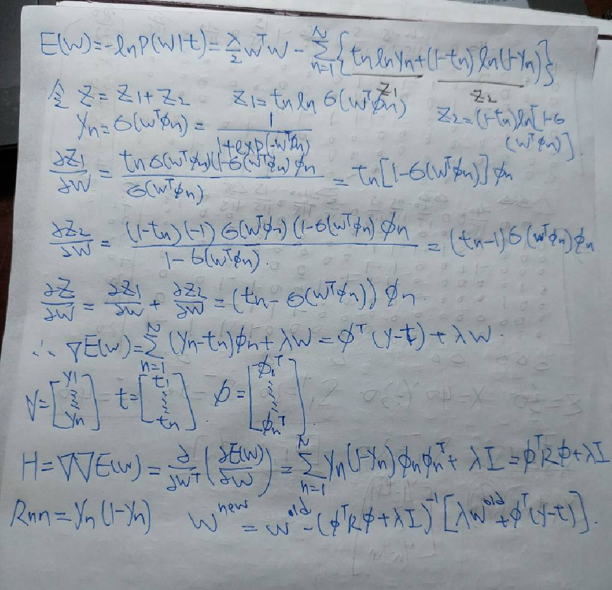

```python
from IPython.core.display import Image, display
display(Image('https://i.imgur.com/qBFqW0K.jpg', width=700, unconfined=True))
```

## Q3.2 (25%) Create your mylogistic_l2 class. Train your model and show the learned $w$ as well as test accuracy for the cases below. If $w$ is too long for you, show selected $w$ for continuous-valued, binary-valued, and the constant term.

```
* Case 1: lambda = 1 for all coefficients
* Case 2: lambda = 1 for all but the intercept, no regularization for intercept term.
* Case 3: lambda = 1 for numerical-valued features, lambda = 0.5 for binary-valued features,
no regularization for intercept term.
```

### Create your mylogistic_l2 class

```python
import numpy as np

class mylogistic_l2():
    def __init__(self, reg_vec, max_iter=100, tol=1e-5, add_intercept=True):
        """reg_vec: the regularization coefficient vector
            max_iter: maximum number of iteration to run for the Newton method
            tol: tolerance for the objective function
            add_intercept: whether to add intercept (a column of ones) at last column of the feature matrix"""
        ### Add your code here
        self.reg_vec = reg_vec
        self.max_iter = max_iter
        self.tol = tol
        self.add_intercept = add_intercept

    def fit(self, x, y, verbal=False):
        # Add your code here\
        if self.add_intercept:
            x = np.hstack((x, np.ones((x.shape[0], 1))))
        b = np.mean(self.reg_vec)
        self.w = np.dot(np.linalg.inv(np.dot(x.T, x) + np.dot(b, np.identity(x.shape[1]))), np.dot(x.T, y))
        self.loss = np.inf
        for _ in range(self.max_iter):
            Y_i = self.sigmoid(np.dot(x, self.w))
            loss = self.calc_loss(Y_i, y)
            if self.loss - loss < self.tol:
                break
            self.loss = loss
            R = np.diag(Y_i * (1 - Y_i))
            hessian = (np.dot(np.dot(np.transpose(x), R), x) + np.diag(self.reg_vec))
            gradient = (np.dot(np.transpose(x), Y_i - y) + self.reg_vec * self.w)
            w_new = self.w - np.dot(np.linalg.inv(hessian), gradient)
            self.w = w_new
            del R, hessian, gradient

    def calc_loss(self, sigmoid_func, y):
        z1 = y * np.log(sigmoid_func)
        z2 = (1 - y) * np.log(1 - sigmoid_func)
        loss = -np.sum(z1 + z2) + np.dot((self.reg_vec * self.w), self.w) * 0.5
        return loss

    @staticmethod
    def sigmoid(param):
        return 1 / (1 + np.exp(-param))

    def predict(self, x):
        """doing prediction"""
        ### add your code here.
        if self.add_intercept:
            x = np.hstack((x, np.ones((x.shape[0], 1))))
        ypred = self.sigmoid(np.dot(x, self.w))
        ypred = np.where(ypred > 0.5, 1, 0)
        return ypred
```

### 重新匯入資料

```python
import pickle

dsfile = 'adult_m50k.pickle'
with open(dsfile, 'rb') as fh1:
    adult50kp = pickle.load(fh1)

x_train = adult50kp['x_train']
y_train = adult50kp['y_train']
x_test = adult50kp['x_test']
y_test = adult50kp['y_test']
columnname = adult50kp['columnname']
num_col = adult50kp['num_col']
```

### Case 1: lambda = 1 for all coefficients

```python
lambda_vec = np.ones(x_train.shape[1]) * 1
lambda_vec = np.hstack((lambda_vec, 1))
log_reg1 = mylogistic_l2(reg_vec=lambda_vec, max_iter=1000, tol=1e-5, add_intercept=True)
log_reg1.fit(x_train, y_train, verbal=True)

ypred = log_reg1.predict(x_test)
acc = np.sum(y_test == ypred) / len(y_test)
print(f'final loss: {log_reg1.loss}')
print(f'learned weights for case 1:\n {log_reg1.w}')
print(f'test accuracy for case 1: {acc}')
```

```
final loss: 9775.247127751614
learned weights for case 1:
 [ 2.58310749e-01  3.52951378e-01  2.33390152e+00  7.51145211e-01
  3.33524430e-01  7.92368680e-02 -2.59305992e-01 -3.31059192e-02
 -8.02092312e-01 -1.16328375e+00 -1.57480268e-01  1.06974336e+00
 -6.33846058e-01  1.16732409e-01 -2.31567381e-01 -5.17122207e-01
 -7.97216465e-02 -1.09949780e+00 -2.46027086e-01  6.19694928e-02
  1.26685884e-01  8.62656059e-01 -9.18352843e-01 -6.21226177e-01
 -2.00740224e-01 -7.51600981e-01 -1.61011588e+00  5.75820911e-01
  6.48995283e-01  3.53741434e-01  7.17218474e-01 -2.84494743e-02
 -9.54820746e-04 -1.96540899e-01 -1.46351640e-01  6.26946275e-01
  4.48207080e-01  2.45945819e-02  4.69223657e-02 -4.91067746e-01
 -2.03035424e-01 -1.63303680e-01 -1.76623501e-02 -1.11328323e-01
 -9.94618240e-02 -1.17391916e+00  1.80702678e-01 -6.92720004e-02
  9.76496905e-01  4.60988601e-01 -4.95440416e-01 -1.27203531e+00
  4.86772406e-01 -8.98963733e-01 -6.00542591e-02 -3.50848853e-01
  4.32815220e-01  5.94120150e-01  5.82151924e-01 -6.20962283e-01
 -5.97480378e-02  9.29035250e-02 -1.51892101e-01 -5.38528893e-03
  3.41609087e-02 -2.89088236e-01  1.56053911e-01  4.95401243e-01
  8.90942264e-01  1.49151436e-01  3.42484779e-01 -3.13312160e-01
 -3.55939108e-01 -3.62494608e-01 -6.67247475e-01 -4.08831130e-01
  4.47489832e-01  1.37768931e-01  1.41351233e-01 -1.16015421e-01
 -5.61032710e-02 -9.34583042e-01 -2.92596523e-02 -2.99012958e-01
 -1.50511251e-01  3.52331870e-01 -7.85846536e-01  5.80200207e-01
  4.97042311e-01 -1.90320740e-01 -3.47717245e-04  1.74993805e-01
 -4.88202695e-01 -3.12259616e-01 -1.02643023e+00 -7.22310834e-01
  1.44672469e+00  1.15520745e+00 -6.80202902e-01 -1.21195630e+00
 -7.98338505e-01 -5.34648484e-01 -1.34552489e+00]
test accuracy for case 1: 0.847875166002656
```

### Case 2: lambda = 1 for all but the intercept, no regularization for intercept term.

```python
lambda_vec = np.ones(x_train.shape[1]) * 1
lambda_vec = np.hstack((lambda_vec, 0))
log_reg2 = mylogistic_l2(reg_vec=lambda_vec, max_iter=1000, tol=1e-5, add_intercept=True)
log_reg2.fit(x_train, y_train, verbal=True)

ypred = log_reg2.predict(x_test)
acc = np.sum(y_test == ypred) / len(y_test)
print(f'final loss: {log_reg2.loss}')
print(f'learned weights for case 2:\n {log_reg2.w}')
print(f'test accuracy for case 2: {acc}')
```

```
final loss: 9773.111189226107
learned weights for case 2:
 [ 0.25833063  0.35307341  2.33348255  0.7378757   0.33385106  0.07926886
 -0.04219572  0.1998764  -0.58360968 -0.93671312  0.07548468  1.28715744
 -0.37140327  0.39422898  0.04305748 -0.26147348  0.19559029 -0.42695771
  0.42695771  0.16424528  0.22840772  0.96472553 -0.81743779 -0.52074423
 -0.09910239 -0.64944042 -1.55235098  0.6786798   0.75066429  0.45541098
  0.81857112  0.07308911  0.0728464  -0.11752644 -0.06282948  0.67242506
  0.5040869   0.08799091  0.11435013 -0.38483984 -0.10196309 -0.05145374
  0.10741777 -0.01997934  0.01717544 -1.16567808  0.30082277  0.02715464
  1.00831207  0.50210397 -0.45756662 -1.24002555  0.52780939 -0.86832688
 -0.02771494 -0.31412701  0.47343435  0.62981111  0.62405658 -0.5867506
 -0.0296708   0.12414401 -0.14376238  0.02434194  0.0621604  -0.24843986
  0.19459429  0.52620501  0.93165615  0.18707696  0.37950109 -0.28749402
 -0.31137357 -0.33290534 -0.65117786 -0.38160106  0.48879121  0.17662205
  0.17410342 -0.07343502 -0.0314651  -0.89846776  0.00653561 -0.27232555
 -0.12442075  0.39697177 -0.75318727  0.61067658  0.70544004  0.01789988
  0.2090388   0.382747   -0.2795817  -0.10453082 -0.9310132  -0.52642474
  1.61398954  1.36735898 -0.49235221 -1.01493649 -0.60567591 -0.34195917
 -3.17508577]
test accuracy for case 2: 0.8477423638778221
```

### Case 3: lambda = 1 for numerical-valued features, lambda = 0.5 for binary-valued features, no regularization for intercept term.

```python
lambda_vec = np.ones(x_train.shape[1]) * 1
lambda_vec[len(num_col):] = 0.5
lambda_vec = np.hstack((lambda_vec, 0))
log_reg3 = mylogistic_l2(reg_vec=lambda_vec, max_iter=1000, tol=1e-5, add_intercept=True)
log_reg3.fit(x_train, y_train, verbal=True)

ypred = log_reg3.predict(x_test)
acc = np.sum(y_test == ypred) / len(y_test)
print(f'final loss: {log_reg3.loss}')
print(f'learned weights for case 3:\n {log_reg3.w}')
print(f'test accuracy for case 3: {acc}')
```

```
final loss: 9764.22260073367
learned weights for case 3:
 [ 0.25851661  0.3533387   2.33562764  0.7825921   0.33439916  0.07940036
 -0.08347988  0.23309134 -0.59278098 -0.9224849   0.11139573  1.25425869
 -0.38299462  0.41291781  0.04136013 -0.26411462  0.19283128 -0.42890321
  0.42890321  0.23635122  0.30021361  1.03810521 -0.75216086 -0.4534137
 -0.02691157 -0.5825269  -2.00075382  0.75127891  0.82696617  0.52830705
  0.89488994  0.14510375  0.18253094 -0.02583999  0.00991404  0.89862004
  0.68517002  0.23294385  0.24519931 -0.38363083 -0.08029608 -0.06493444
  0.0453608   0.03743376 -0.01295908 -2.09374319  0.25763304  0.06659781
  1.18748312  0.55059265 -0.47576613 -1.45842154  0.5822242  -1.0627833
 -0.00957211 -0.31704572  0.52485137  0.73044517  0.67457228 -0.63624179
 -0.00967268  0.17339113 -0.2364757   0.0375474   0.10120874 -0.24679341
  0.23800627  0.64228457  1.00567032  0.23258941  0.42267607 -0.35336167
 -0.29178766 -0.38125401 -0.96291964 -0.45007954  0.512985    0.22019382
  0.22640627 -0.04989103 -0.01836864 -0.95953334  0.01656804 -0.32741555
 -0.14011404  0.42856024 -0.84476926  0.75121645  0.76670733  0.07638783
  0.26824615  0.44314098 -0.2205815  -0.04631789 -1.28758289 -0.57187068
  1.82502287  1.39622511 -0.54691696 -1.05894077 -0.65551468 -0.38800489
 -3.36269033]
test accuracy for case 3: 0.847675962815405
```

### Q3.3 (10%) Further split the training data into subtraining (90%) and tuning (10%) to search for the best hyperparameters. Set the regularization coefficient for the constant term to zero. Allow different regularizations for continuous-valued and binary-valued features. Let 𝑎1 and 𝑎2 denote the regularization coefficients for continuous-valued and binary-valued features. Search the best 𝑎1 and 𝑎2 and report the test accuracy using the best hyper-parameters. You should follow the following procedure to search for the best hyperparameters.

step1 : Choose a set of grids among a reasonable range. For example, 10 grids in [0.01, 100]

step2 : Conduct grid search with the constraint that 𝑎1=𝑎2 . Record the best value 𝑎∗1 and 𝑎∗2

step3 : Fix 𝑎1=𝑎∗1 , and search 𝑎2 for the best value, call the result the new 𝑎∗2 .

step4 : Fix 𝑎2=𝑎∗2 , and search 𝑎1 for the best value.

step5 : Report the selected 𝑎1 and 𝑎2 .

step6 : Train a model using the selected hyper-parameters, and report the test accuracy.

```python
from sklearn.model_selection import train_test_split

##step 0 split the training data into subtraining (90%) and tuning (10%) to search for the best hyperparameters
x_subtrain, x_tune, y_subtrain, y_tune = train_test_split(x_train, y_train, train_size=0.9,random_state=50)

## step 1 Choose a set of grids among a reasonable range
grids = [0.01, 0.05, 0.1, 0.5, 1, 5, 10, 40, 70, 100]
acc_list = np.zeros(len(grids))

## step 2 Conduct grid search with the constraint that 𝑎1=𝑎2
for idx, grid in enumerate(grids):
    lambda_vec = np.ones(x_subtrain.shape[1]) * grid
    lambda_vec = np.hstack((lambda_vec, 0))
    log_reg4 = mylogistic_l2(reg_vec=lambda_vec, max_iter=1000, tol=1e-5, add_intercept=True)
    log_reg4.fit(x_subtrain, y_subtrain, verbal=True)

    ypred = log_reg4.predict(x_tune)
    acc = np.sum(y_tune == ypred) / len(y_tune)
    acc_list[idx] = acc
    print(f'grid: {round(grid, 2)} , test accuracy for grid search with 𝑎1=𝑎2 : {acc}')

print(f'a1*:{grids[np.argmax(acc_list)]}')
print(f'a2*:{grids[np.argmax(acc_list)]}')
print('step 2 finished')

## step 3  Fix 𝑎1=𝑎∗1 , and search 𝑎2 for the best value
a1_star = grids[np.argmax(acc_list)]
print(f'fixed a1* at {a1_star}')

for idx, grid in enumerate(grids):
    lambda_vec = np.ones(x_subtrain.shape[1]) * a1_star
    lambda_vec[len(num_col):] = grid
    lambda_vec = np.hstack((lambda_vec, 0))
    log_reg4 = mylogistic_l2(reg_vec=lambda_vec, max_iter=1000, tol=1e-5, add_intercept=True)
    log_reg4.fit(x_subtrain, y_subtrain, verbal=True)

    ypred = log_reg4.predict(x_tune)
    acc = np.sum(y_tune == ypred) / len(y_tune)
    acc_list[idx] = acc
    print(f'grid: {round(grid, 2)} , test accuracy for fixed a1*: {acc}')

print('step 3 finished')
## step 4 Fix 𝑎2=𝑎∗2 , and search  𝑎1  for the best value
a2_star = grids[np.argmax(acc_list)]
print(f'fixed a2* at {a2_star}')

for idx, grid in enumerate(grids):
    lambda_vec = np.ones(x_subtrain.shape[1]) * grid
    lambda_vec[len(num_col):] = a2_star
    lambda_vec = np.hstack((lambda_vec, 0))
    log_reg4 = mylogistic_l2(reg_vec=lambda_vec, max_iter=1000, tol=1e-5, add_intercept=True)
    log_reg4.fit(x_subtrain, y_subtrain, verbal=True)

    ypred = log_reg4.predict(x_tune)
    acc = np.sum(y_tune == ypred) / len(y_tune)
    acc_list[idx] = acc
    print(f'grid: {round(grid, 2)} , test accuracy for fixed a2*: {acc}')

a1_star = grids[np.argmax(acc_list)]
print('step 4 finished')
##step 5 Report the selected  𝑎1  and  𝑎2 .
print(f'The best hyperparameters after the grid serach a1:{a1_star} a2:{a2_star}')
print('step 5 finished')

##step 6 Train a model using the selected hyper-parameters, and report the test accuracy.
lambda_vec = np.ones(x_train.shape[1]) * a1_star
lambda_vec[len(num_col):] = a2_star
lambda_vec = np.hstack((lambda_vec, 0))
my_log_reg = mylogistic_l2(reg_vec=lambda_vec, max_iter=1000, tol=1e-5, add_intercept=True)
my_log_reg.fit(x_train, y_train, verbal=True)

ypred = my_log_reg.predict(x_test)
acc_mylogic = np.sum(y_test == ypred) / len(y_test)
print(f'my logic final loss: {my_log_reg.loss}')
print(f'my logic learned weights for my logistic regression :\n {my_log_reg.w}')
print(f'my logic test accuracy for my logistic regression : {acc_mylogic}')
print('step 6 finished')
```

```
grid: 0.01 , test accuracy for grid search with 𝑎1=𝑎2 : 0.8428902883659264
grid: 0.05 , test accuracy for grid search with 𝑎1=𝑎2 : 0.8428902883659264
grid: 0.1 , test accuracy for grid search with 𝑎1=𝑎2 : 0.8425588332780908
grid: 0.5 , test accuracy for grid search with 𝑎1=𝑎2 : 0.8425588332780908
grid: 1 , test accuracy for grid search with 𝑎1=𝑎2 : 0.843221743453762
grid: 5 , test accuracy for grid search with 𝑎1=𝑎2 : 0.8428902883659264
grid: 10 , test accuracy for grid search with 𝑎1=𝑎2 : 0.843221743453762
grid: 40 , test accuracy for grid search with 𝑎1=𝑎2 : 0.8412330129267485
grid: 70 , test accuracy for grid search with 𝑎1=𝑎2 : 0.8385813722240636
grid: 100 , test accuracy for grid search with 𝑎1=𝑎2 : 0.8382499171362281
a1*:1
a2*:1
step 2 finished
fixed a1* at 1
grid: 0.01 , test accuracy for fixed a1*: 0.8425588332780908
grid: 0.05 , test accuracy for fixed a1*: 0.8425588332780908
grid: 0.1 , test accuracy for fixed a1*: 0.8425588332780908
grid: 0.5 , test accuracy for fixed a1*: 0.8425588332780908
grid: 1 , test accuracy for fixed a1*: 0.843221743453762
grid: 5 , test accuracy for fixed a1*: 0.843221743453762
grid: 10 , test accuracy for fixed a1*: 0.8422273781902552
grid: 40 , test accuracy for fixed a1*: 0.8418959231024197
grid: 70 , test accuracy for fixed a1*: 0.8395757374875704
grid: 100 , test accuracy for fixed a1*: 0.8382499171362281
step 3 finished
fixed a2* at 1
grid: 0.01 , test accuracy for fixed a2*: 0.843221743453762
grid: 0.05 , test accuracy for fixed a2*: 0.843221743453762
grid: 0.1 , test accuracy for fixed a2*: 0.843221743453762
grid: 0.5 , test accuracy for fixed a2*: 0.843221743453762
grid: 1 , test accuracy for fixed a2*: 0.843221743453762
grid: 5 , test accuracy for fixed a2*: 0.843221743453762
grid: 10 , test accuracy for fixed a2*: 0.8435531985415976
grid: 40 , test accuracy for fixed a2*: 0.8442161087172688
grid: 70 , test accuracy for fixed a2*: 0.8422273781902552
grid: 100 , test accuracy for fixed a2*: 0.8412330129267485
step 4 finished
The best hyperparameters after the grid serach a1:40 a2:1
step 5 finished
my logic final loss: 9871.527559990407
my logic learned weights for my logistic regression :
 [ 0.24965575  0.34504508  1.92609804  0.38495889  0.32688625  0.07776747
 -0.04324037  0.21262552 -0.5849748  -0.93065303  0.0791417   1.26710097
 -0.35217082  0.38972622  0.04310829 -0.26885773  0.18819403 -0.42168623
  0.42168623  0.16684656  0.22749249  0.96081007 -0.80103756 -0.5216471
 -0.10005616 -0.65512161 -1.52237406  0.68389999  0.74001609  0.45496619
  0.81262081  0.07051632 -0.34096326 -0.37452517 -0.19570576 -0.12002784
 -0.23574839 -0.56463694 -0.42240817  0.01687006  0.16840428  0.48556987
  1.02835571 -0.02441509  0.69122598 -1.35697134  1.08897282  0.15600326
  0.97454111  0.49536375 -0.43775426 -1.22802826  0.52849021 -0.88837015
 -0.03095849 -0.28030356  0.49086997  0.65781331  0.62993038 -0.53722963
 -0.02724356  0.1044868  -0.14917781  0.0098693   0.08112622 -0.24052334
  0.18840746  0.53139916  0.92669656  0.1710541   0.3767044  -0.29471979
 -0.33376203 -0.3482815  -0.66305273 -0.39219814  0.48259968  0.18516344
  0.16265888 -0.0669209  -0.04273341 -0.89552549 -0.00113039 -0.2769108
 -0.13921728  0.40251557 -0.72622326  0.61529934  0.69818899  0.02042811
  0.20694937  0.38462742 -0.27237836 -0.10556828 -0.93224726 -0.52271273
  1.59738193  1.36213284 -0.48799198 -1.00510215 -0.60383016 -0.33987775
 -3.34122465]
my logic test accuracy for my logistic regression : 0.8479415670650731
step 6 finished
```

### Q3.4 (5%) Use sklearn.linear_model.LogisticRegression to train and test the model (including hyperparameter tuning). Compare the estimated parameters and test accuracy with those from your own models.

```python
from sklearn.linear_model import LogisticRegression

for idx, grid in enumerate(grids):
    sk_log_reg = LogisticRegression(penalty='l2', tol=1e-5, max_iter=1000, C=grid)
    sk_log_reg.fit(x_subtrain, y_subtrain)
    ypred = sk_log_reg.predict(x_tune)
    acc = np.sum(y_tune == ypred) / len(y_tune)
    acc_list[idx] = acc

print(grids[np.argmax(acc_list)])

sk_log_reg = LogisticRegression(penalty='l2', tol=1e-5, max_iter=1000, C=grids[np.argmax(acc_list)])
sk_log_reg.fit(x_subtrain, y_subtrain)
ypred = sk_log_reg.predict(x_tune)
acc_sklogic = np.sum(y_tune == ypred) / len(y_tune)
print(f'sklearn logic learned weights :\n {sk_log_reg.coef_}')
print(f'sklearn logic test accuracy : {acc_sklogic}')

##compare sklearn with mylogic
print(f'mylogistic_l2 parameters:\n{my_log_reg.w[:-1]}')
print(f'my logic test accuracy : {acc_mylogic}')
print(f'每個weight平均差 {np.mean(np.abs(my_log_reg.w[:-1] - sk_log_reg.coef_))}')
print(f'my logic和sklearn logic 準確率比較:{acc_mylogic-acc_sklogic}' )
```

```
0.5
sklearn logic learned weights :
 [[ 0.25197046  0.34019558  2.31038077  0.71113853  0.32512127  0.08402681
   0.02630646  0.15344199 -0.58254076 -0.98697412  0.03979098  1.34392923
  -0.33307595  0.35122043  0.03070815 -0.24468874  0.18978989 -0.43032899
   0.42428277  0.08728364  0.14451054  0.92091078 -0.86183503 -0.53003455
  -0.13290051 -0.76570329 -1.05210979  0.61595019  0.67438132  0.40151736
   0.77950903  0.000822    0.04434649 -0.14937744 -0.04299472  0.37716841
   0.40834153  0.06538065 -0.01393182 -0.3989898  -0.13404953 -0.03615792
   0.19758292 -0.04197775  0.06528139 -0.64030905  0.28867673  0.00496368
   0.84604477  0.23910476 -0.54641339 -0.95004913  0.43149681 -0.62637178
  -0.01719497 -0.19485424  0.29527467  0.51263813  0.58832901 -0.19371297
   0.06566198 -0.09015521 -0.08054558 -0.14537227  0.1077825  -0.30584888
   0.35151367  0.30613368  0.90154014  0.03757746  0.26801663 -0.1822028
  -0.40700457 -0.26192758 -0.3754299  -0.26858448  0.4760619   0.08778892
   0.15843543 -0.09468976 -0.02810326 -0.66418366 -0.08749556 -0.14526751
  -0.05006318  0.38398834 -0.55800564  0.2177969   0.66178302 -0.02461629
   0.14047942  0.32639834 -0.3271573  -0.15862599 -0.62430742 -0.46192698
   1.39442712  1.32105845 -0.51054018 -0.96266189 -0.47613246 -0.31027029]]
sklearn logic test accuracy : 0.8435531985415976
mylogistic_l2 parameters:
[ 0.24965575  0.34504508  1.92609804  0.38495889  0.32688625  0.07776747
 -0.04324037  0.21262552 -0.5849748  -0.93065303  0.0791417   1.26710097
 -0.35217082  0.38972622  0.04310829 -0.26885773  0.18819403 -0.42168623
  0.42168623  0.16684656  0.22749249  0.96081007 -0.80103756 -0.5216471
 -0.10005616 -0.65512161 -1.52237406  0.68389999  0.74001609  0.45496619
  0.81262081  0.07051632 -0.34096326 -0.37452517 -0.19570576 -0.12002784
 -0.23574839 -0.56463694 -0.42240817  0.01687006  0.16840428  0.48556987
  1.02835571 -0.02441509  0.69122598 -1.35697134  1.08897282  0.15600326
  0.97454111  0.49536375 -0.43775426 -1.22802826  0.52849021 -0.88837015
 -0.03095849 -0.28030356  0.49086997  0.65781331  0.62993038 -0.53722963
 -0.02724356  0.1044868  -0.14917781  0.0098693   0.08112622 -0.24052334
  0.18840746  0.53139916  0.92669656  0.1710541   0.3767044  -0.29471979
 -0.33376203 -0.3482815  -0.66305273 -0.39219814  0.48259968  0.18516344
  0.16265888 -0.0669209  -0.04273341 -0.89552549 -0.00113039 -0.2769108
 -0.13921728  0.40251557 -0.72622326  0.61529934  0.69818899  0.02042811
  0.20694937  0.38462742 -0.27237836 -0.10556828 -0.93224726 -0.52271273
  1.59738193  1.36213284 -0.48799198 -1.00510215 -0.60383016 -0.33987775]
my logic test accuracy : 0.8479415670650731
每個weight平均差 0.15644118167295035
my logic和sklearn logic 準確率比較:0.004388368523475461
```

## Q3小結

為了方便觀察結果，設置random_state=50固定切分subtrain和tune，從以上數據結果可得知my logic比sklearn logic預測更加準確，推測可能原因發生在資料的切分上，不同的切分會造成不同的結果，有些切分結果會造成sklearn logic反而預測更加準確，然而準確率兩者相差不大(0.004)，每個weight平均僅差0.15，由此可以推斷自行製作的邏輯斯回歸演算法與sklearn中的邏輯斯回歸演算法具有一定程度的相似。